# CSCI E-106:Assignment 3

### Submitted by : Gurdeep Singh

### Due Date: September 28, 2020 at 7:20 pm EST

### Instructions

Students should submit their reports on Canvas. The report needs to clearly state what question is being solved, step-by-step walk-through solutions, and final answers clearly indicated. Please solve by hand where appropriate.

Please submit two files: (1) a R Markdown file (.Rmd extension) and (2) a PDF document, word, or html generated using knitr for the .Rmd file submitted in (1) where appropriate. Please, use RStudio Cloud for your solutions.

## Problem 1

Five observations on Y are to be taken when X = 4, 8, 12, 16, and 20, respectively. The true regression function is E(Y} = 20 + 4X, and the $\epsilon_i$ are independent N(O, 25). (40 points, 10 points each)

a-) Generate five normal random numbers, with mean 0 and variance 25. Consider these random numbers as the error terms for the five Y observations at X = 4,8, 12, 16, and 20 and calculate $Y_1$, $Y_2$, $Y_3$, $Y_4$ , and $Y_5$. Obtain the least squares estimates $b_0$ and $b_1$, when fitting a straight line to the five cases. Also calculate $Y_h$ when $X_h$ = 10 and obtain a 95 percent confidence interval for E($Y_h$) when $X_h$ = 10.

```r
library(knitr)

rm(list = ls())

set.seed(1023)
x_i <- c(4,8,12,16,20)
err_i <- rnorm(5,0,25) # 5 normal random numbers
y_i_est <- 20 + (4*x_i) + err_i # calculate y_i
err_i; y_i_est # print results
```

```
## [1] -16.912784  41.043154  -5.924756  23.948839 -21.286074
```

```
## [1]  19.08722  93.04315  62.07524 107.94884  78.71393
```

```r
# fit regression and get summary
reg_q1a <- lm(y_i_est~x_i)
summary(reg_q1a)
```

```
##
## Call:
## lm(formula = y_i_est ~ x_i)
##
## Residuals:
##      1      2      3      4      5
## -26.25  34.29 -10.10  22.36 -20.29
##
## Coefficients:
##             Estimate Std. Error t value Pr(>|t|)
## (Intercept)   31.926     32.487   0.983    0.398
## x_i            3.354      2.449   1.370    0.264
##
## Residual standard error: 30.98 on 3 degrees of freedom
## Multiple R-squared:  0.3847, Adjusted R-squared:  0.1796
## F-statistic: 1.876 on 1 and 3 DF,  p-value: 0.2643
```

```r
# calculate E(Y_h) and 95% CI when X_h = 10
x_h <- 10
#y_h <- 20 + (4*xh)
e_y_h <- predict(reg_q1a, data.frame(x_i=x_h), interval = 'confidence', level = 0.95, se.fit = TRUE)
e_y_h
```

```
## $fit
##        fit      lwr      upr
## 1 65.46572 18.70604 112.2254
##
## $se.fit
## [1] 14.693
##
## $df
## [1] 3
##
## $residual.scale
## [1] 30.97556
```

Least square estimates are $\beta_O$ = 31.926 and $\beta_1$ = 3.354 ${Y_h}$ = 65.46 and 95% CI are 18.70604 and 112.2254

b-) Repeat part (a) 200 times, generating new random numbers each time.

```r
n_iter <- 200
b0_1b <- vector(mode = 'integer', length = n_iter)
b1_1b <- vector(mode = 'integer', length = n_iter)
yh_1b <- vector(mode = 'integer', length = n_iter)
yh_lwr_1b <- vector(mode = 'integer', length = n_iter)
yh_upr_1b <- vector(mode = 'integer', length = n_iter)

for (i in 1:n_iter) {
  #print(i)
  err_x <- rnorm(length(x_i), 0, 25)
  y_i_iter <- 20 + (4*x_i) + err_x
  reg_iter <- lm(y_i_iter~x_i)
  b0_1b[i] <- reg_iter$coefficients[1]
  b1_1b[i] <- reg_iter$coefficients[2]
  yh_1b_pred <- predict(reg_iter, data.frame(x_i = x_h), level = 0.95, interval = 'confidence')
  yh_1b[i] <- yh_1b_pred[1]
  yh_lwr_1b[i] <- yh_1b_pred[2]
  yh_upr_1b[i] <- yh_1b_pred[3]
}

# printing 1st 50 values as per piazza discussion
print(yh_1b[1:50])
```

```
##  [1] 55.10618 75.51912 70.88132 72.39643 66.93567 90.73924 50.25102
##  [8] 54.21873 57.45286 69.60007 51.63278 41.78010 58.44969 63.22350
## [15] 67.60458 51.23096 50.68991 53.59838 68.10728 67.63649 59.88138
## [22] 63.52194 72.07590 74.98249 38.54589 81.72762 60.32362 54.41963
## [29] 72.98257 45.75487 61.15036 60.54929 67.25990 63.23705 60.59071
## [36] 61.02299 47.71565 26.18363 59.70777 64.32756 64.85359 49.81770
## [43] 72.88648 88.75179 58.53920 57.40047 67.96887 58.08132 41.62736
## [50] 66.52389
```

```r
print(yh_lwr_1b[1:50])
```

```
##  [1]  0.3434255  1.8145238 32.8997585 57.5654634 49.1001136 64.2539869
##  [7] 17.3903106 -1.2242766  7.7341764 53.3225790 23.0590316 26.8366466
## [13] 18.2229252 21.9180222 31.9229124 36.6230383 44.3972814 28.4669606
## [19] 56.3417636 30.5966843 18.6873375 42.5774898 54.1097204 37.0633848
## [25]  6.1551299 65.2930645 25.6725940 29.6082419 44.7061174 24.3216442
## [31] 24.4539907 17.3225678  3.0395190  7.2010617 22.2338510 30.8201064
## [37] 13.0208963 -9.4804702 26.7284485 38.1467770 52.4263973 27.4125388
## [43] 43.1260108 65.5840812 36.9641807 30.3629523 43.9864021 32.1850782
## [49] -3.2350074 25.0574860
```

```r
print(yh_upr_1b[1:50])
```

```
##  [1] 109.86894 149.22371 108.86288  87.22739  84.77124 117.22450  83.11173
##  [8] 109.66174 107.17154  85.87756  80.20653  56.72356  98.67645 104.52898
## [15] 103.28625  65.83889  56.98253  78.72980  79.87280 104.67629 101.07541
## [22]  84.46640  90.04207 112.90160  70.93665  98.16218  94.97465  79.23101
## [29] 101.25901  67.18810  97.84673 103.77601 131.48028 119.27303  98.94758
## [36]  91.22588  82.41041  61.84774  92.68709  90.50834  77.28079  72.22285
## [43] 102.64694 111.91949  80.11423  84.43798  91.95133  83.97757  86.48974
## [50] 107.99030
```

c-) Make a frequency distribution of the 200 estimates $b_1$. Calculate the mean and standard deviation of the 200 estimates $b_1$. Are the results consistent with theoretical expectations?

```r
# calculate mean of distribution from 1b above
b1_mean_1c <- mean(b1_1b)
b1_sd_1c <- sd(b1_1b)
b1_mean_1c; b1_sd_1c
```

```
## [1] 3.768963
```

```
## [1] 2.011892
```

```r
# calculate theoretical value of b1
xi_xbar <- x_i - mean(x_i)
yi_ybar <- y_i_est - mean(y_i_est)
b1_th_nr_1c <- sum(xi_xbar * yi_ybar)
b1_th_dr_1c <- sum((xi_xbar)^2)
b1_th_1c <- b1_th_nr_1c/b1_th_dr_1c
b1_th_1c
```

```
## [1] 3.353978
```

```r
# calculate theoretical value of sd(b1)
s2_b1_th_nr <- sum((y_i_est - reg_q1a$fitted.values)^2)/(length(x_i)-2)
s2_b1_th_dr <- sum((xi_xbar)^2)
s2_b1_th <- s2_b1_th_nr/s2_b1_th_dr
s2_b1_th
```

```
## [1] 5.996784
```

```r
sd_b1_th_1c <- sqrt(s2_b1_th)
sd_b1_th_1c
```

```
## [1] 2.448833
```

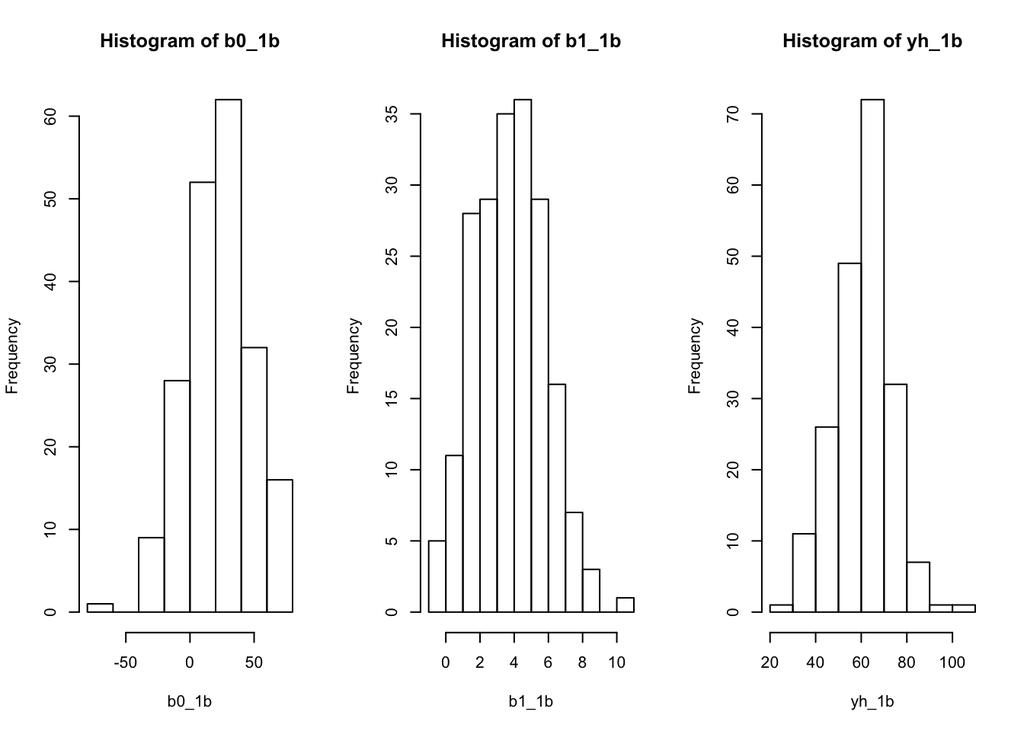

```r
# Plot the data
par(mfrow = c(1,3))
hist(b0_1b)
hist(b1_1b)
hist(yh_1b)
```

Theoretical mean = 3.353978; calculated mean = 3.768963 Theoretical sd = 2.448833; calculated sd = 2.011892

The values from the mean and SD of the distributions in 1(b) vary by 12% - 20% from the theoretical values above.

This variation is acceptable given that we have calculated mean values using only 200 repetitions. With higher repetition the varation between calculated and theoretical values is likely to be reduced.

d-) What proportion of the 200 confidence intervals for E($Y_h$) when $X_h$ = 10 include E($Y_h$)? Is this result consistent with theoretical expectations?

```r
yh_confint_1d <- data.frame(yh_lwr_1b, yh_upr_1b)
head(yh_confint_1d)
```

|  | yh_lwr_1b | yh_upr_1b |
| --- | --- | --- |
| 1 | 0.3434255 | 109.86894 |
| 2 | 1.8145238 | 149.22371 |
| 3 | 32.8997585 | 108.86288 |
| 4 | 57.5654634 | 87.22739 |
| 5 | 49.1001136 | 84.77124 |
| 6 | 64.2539869 | 117.22450 |

```r
yh_incl_eh <- subset(yh_confint_1d, yh_lwr_1b < 60 & yh_upr_1b > 60)
(dim(yh_incl_eh)[1]/n_iter)*100 # percent of iterations that have E(Y_h)
```

```
## [1] 92
```

Since 92% of the observations fall within the confidence interval these results are not consistent with theoretical expectations of 95% CI

## Problem 2

Refer to the CDI data set (used in homework 1). The number of active physicians in a CDI (Y) is expected to be related to total population, number of hospital beds, and total personal income. Using $R^2$ as the criterion, which predictor variable accounts for the largest reduction in the variability in the number of active physicians? (20 Point)

```r
cdi <- read.csv("CDI Data.csv")
head(cdi)
```

|  | Identification.number | County | State | Land.area | Total.population | Percent.of.population.aged.18.34 | Percent.of.population.65.or.older | Number.of.active.physicians | Number.of.hospital.beds | Total.serious.crimes | Percent.high.school.graduates | Percent.bachelor.s.degrees | Percent.below.poverty.level | Percent.unemployment | Per.capita.income | Total.personal.income | Geographic.region |
| --- | --- | --- | --- | --- | --- | --- | --- | --- | --- | --- | --- | --- | --- | --- | --- | --- | --- |
| 1 | 1 | Los_Angeles | CA | 4060 | 8863164 | 32.1 | 9.7 | 23677 | 27700 | 688936 | 70.0 | 22.3 | 11.6 | 8.0 | 20786 | 184230 | 4 |
| 2 | 2 | Cook | IL | 946 | 5105067 | 29.2 | 12.4 | 15153 | 21550 | 436936 | 73.4 | 22.8 | 11.1 | 7.2 | 21729 | 110928 | 2 |
| 3 | 3 | Harris | TX | 1729 | 2818199 | 31.3 | 7.1 | 7553 | 12449 | 253526 | 74.9 | 25.4 | 12.5 | 5.7 | 19517 | 55003 | 3 |
| 4 | 4 | San_Diego | CA | 4205 | 2498016 | 33.5 | 10.9 | 5905 | 6179 | 173821 | 81.9 | 25.3 | 8.1 | 6.1 | 19588 | 48931 | 4 |
| 5 | 5 | Orange | CA | 790 | 2410556 | 32.6 | 9.2 | 6062 | 6369 | 144524 | 81.2 | 27.8 | 5.2 | 4.8 | 24400 | 58818 | 4 |
| 6 | 6 | Kings | NY | 71 | 2300664 | 28.3 | 12.4 | 4861 | 8942 | 680966 | 63.7 | 16.6 | 19.5 | 9.5 | 16803 | 38658 | 1 |

```r
reg_q2_tot_pop <- lm(Number.of.active.physicians~Total.population, data = cdi)
summary(reg_q2_tot_pop)
```

```
##
## Call:
## lm(formula = Number.of.active.physicians ~ Total.population,
##     data = cdi)
##
## Residuals:
##     Min      1Q  Median      3Q     Max
## -1969.4  -209.2   -88.0    27.9  3928.7
##
## Coefficients:
##                    Estimate Std. Error t value Pr(>|t|)
## (Intercept)      -1.106e+02  3.475e+01  -3.184  0.00156 **
## Total.population  2.795e-03  4.837e-05  57.793  < 2e-16 ***
## ---
## Signif. codes:  0 '***' 0.001 '**' 0.01 '*' 0.05 '.' 0.1 ' ' 1
##
## Residual standard error: 610.1 on 438 degrees of freedom
## Multiple R-squared:  0.8841, Adjusted R-squared:  0.8838
## F-statistic:  3340 on 1 and 438 DF,  p-value: < 2.2e-16
```

```r
reg_q2_num_beds <- lm(Number.of.active.physicians~Number.of.hospital.beds, data = cdi)
summary(reg_q2_num_beds)
```

```
##
## Call:
## lm(formula = Number.of.active.physicians ~ Number.of.hospital.beds,
##     data = cdi)
##
## Residuals:
##     Min      1Q  Median      3Q     Max
## -3133.2  -216.8   -32.0    96.2  3611.1
##
## Coefficients:
##                          Estimate Std. Error t value Pr(>|t|)
## (Intercept)             -95.93218   31.49396  -3.046  0.00246 **
## Number.of.hospital.beds   0.74312    0.01161  63.995  < 2e-16 ***
## ---
## Signif. codes:  0 '***' 0.001 '**' 0.01 '*' 0.05 '.' 0.1 ' ' 1
##
## Residual standard error: 556.9 on 438 degrees of freedom
## Multiple R-squared:  0.9034, Adjusted R-squared:  0.9032
## F-statistic:  4095 on 1 and 438 DF,  p-value: < 2.2e-16
```

```r
reg_q2_tot_income <- lm(Number.of.active.physicians~Total.personal.income, data = cdi)
summary(reg_q2_tot_income)
```

```
##
## Call:
## lm(formula = Number.of.active.physicians ~ Total.personal.income,
##     data = cdi)
##
## Residuals:
##     Min      1Q  Median      3Q     Max
## -1926.6  -194.5   -66.6    44.2  3819.0
##
## Coefficients:
##                        Estimate Std. Error t value Pr(>|t|)
## (Intercept)           -48.39485   31.83333   -1.52    0.129
## Total.personal.income   0.13170    0.00211   62.41   <2e-16 ***
## ---
## Signif. codes:  0 '***' 0.001 '**' 0.01 '*' 0.05 '.' 0.1 ' ' 1
##
## Residual standard error: 569.7 on 438 degrees of freedom
## Multiple R-squared:  0.8989, Adjusted R-squared:  0.8987
## F-statistic:  3895 on 1 and 438 DF,  p-value: < 2.2e-16
```

Number of hospital beds has a $R^2$ of 0.9034 and hence accounts for the largest reduction in variability in the number of active physicians.

## Problem 3

Refer to the CDI data set (use in previous homework). For each geographic region, regress per capita income in a CDI (Y) against the percentage of individuals in a county having at least a bachelor’s degree (X). Obtain a separate interval estimate of $\beta_1$, for each region. Use a 90 percent confidence coefficient in each case. Do the regression lines for the different regions appear to have similar slopes? (20 points)

```r
table(cdi$Geographic.region) # shows 4 geographies with count of 103, 108, 152 and 77
```

```
##
##   1   2   3   4
## 103 108 152  77
```

```r
geo1 <- subset(cdi, Geographic.region == 1, select = c(Per.capita.income, Percent.bachelor.s.degrees))
# visually verified 103 obs with output of table function
geo1_p3_reg <- lm(Per.capita.income~Percent.bachelor.s.degrees, data = geo1)
confint(geo1_p3_reg, level = 0.9)
```

```
##                                  5 %     95 %
## (Intercept)                7809.8077 10637.82
## Percent.bachelor.s.degrees  460.5177   583.80
```

```r
geo1_p3_reg$coefficients[2]
```

```
## Percent.bachelor.s.degrees
##                   522.1588
```

```r
geo2 <- subset(cdi, Geographic.region == 2, select = c(Per.capita.income, Percent.bachelor.s.degrees))
# visually verified 108 obs with output of table function
geo2_p3_reg <- lm(Per.capita.income~Percent.bachelor.s.degrees, data = geo2)
confint(geo2_p3_reg, level = 0.9)
```

```
##                                   5 %      95 %
## (Intercept)                12627.0363 14535.774
## Percent.bachelor.s.degrees   193.4858   283.853
```

```r
geo2_p3_reg$coefficients[2]
```

```
## Percent.bachelor.s.degrees
##                   238.6694
```

```r
geo3 <- subset(cdi, Geographic.region == 3, select = c(Per.capita.income, Percent.bachelor.s.degrees))
# visually verified 152 obs with output of table function
geo3_p3_reg <- lm(Per.capita.income~Percent.bachelor.s.degrees, data = geo3)
confint(geo3_p3_reg, level = 0.9)
```

```
##                                  5 %       95 %
## (Intercept)                9516.0773 11543.4929
## Percent.bachelor.s.degrees  285.7076   375.5158
```

```r
geo3_p3_reg$coefficients[2]
```

```
## Percent.bachelor.s.degrees
##                   330.6117
```

```r
geo4 <- subset(cdi, Geographic.region == 4, select = c(Per.capita.income, Percent.bachelor.s.degrees))
# visually verified 77 obs with output of table function
geo4_p3_reg <- lm(Per.capita.income~Percent.bachelor.s.degrees, data = geo4)
confint(geo4_p3_reg, level = 0.9)
```

```
##                                  5 %       95 %
## (Intercept)                6862.6967 10367.4086
## Percent.bachelor.s.degrees  364.7585   515.8729
```

```r
geo4_p3_reg$coefficients[2]
```

```
## Percent.bachelor.s.degrees
##                   440.3157
```

As seen above the regression lines have different slopes with largest value being more than double of smallest value

## Problem 4

In a small-scale regression study, five observatiol)s on Y were obtained corresponding to X = 1, 4,10, ll, and 14. Assume that $\sigma$ = .6, $\beta_0$ = 5, and $\beta_1$, = 3. (20 points, 10 points each)

a-) What are the expected values MSR and MSE?

```r
x_4a <- c(1,4,10,11,14)
sigma <- 0.6
beta0_4a <- 5
beta1_4a <- 3

exp_mse_4a <- sigma^2
exp_mse_4a
```

```
## [1] 0.36
```

```r
exp_msr_4a <- exp_mse_4a + (beta1_4a)*sum((x_4a - mean(x_4a))^2)
exp_msr_4a
```

```
## [1] 342.36
```

b-) For determining whether or not a regression relation exists, would it have been better or worse to have made the five observations at X = 6,7, 8, 9, and 1O? Why? Would the same answer apply if the principal purpose were to estimate the mean response for X = 8? Discuss.

```r
x_4b <- c(6,7,8,9,10)
xh_4b <- 8

exp_msr_4b <- exp_mse_4a + (beta1_4a)*sum((x_4b - mean(x_4b))^2)
exp_msr_4b
```

```
## [1] 30.36
```

The numbers in 4a are better suited to determine whether a regression relation exists since they have a higher MSR. This means that a higher amount of variation is explained by the regression.